# Writeup PA 1 Practical Machine Learning

Juan Sebastian Jaramillo

July 24, 2015

## Introduction

Using devices such as Jawbone Up, Nike FuelBand, and Fitbit it is now possible to collect a large amount of data about personal activity relatively inexpensively. These type of devices are part of the quantified self movement ??? a group of enthusiasts who take measurements about themselves regularly to improve their health, to find patterns in their behavior, or because they are tech geeks. One thing that people regularly do is quantify how much of a particular activity they do, but they rarely quantify how well they do it. In this project, your goal will be to use data from accelerometers on the belt, forearm, arm, and dumbell of 6 participants.

The goal of this project is to predict the exercise that a set of people (20) did based on the measurements present in the dataset.

## Data Preprocessing

Let us first load our training data to make the whole analysis for the classifier. We use the dataset generously given in the webpage: **http://groupware.les.inf.puc-rio.br/har**.

```r
training <- read.csv("training.csv",sep = ",", header=TRUE)
```

It is needed to emphasize here that a pre-preprcessing was made since the csv was not being correclty loaded. Give a header for the first column and then it will be correctly loaded as a data frame from a csv.

```r
dim(training)
```

```
## [1] 19622   160
```

```r
str(training)
```

```
## 'data.frame':    19622 obs. of  160 variables:
##  $ num                     : int  1 2 3 4 5 6 7 8 9 10 ...
##  $ user_name               : Factor w/ 6 levels "adelmo","carlitos",..: 2 2 2 2 2 2 2 2 2 2 ...
##  $ raw_timestamp_part_1    : int  1323084231 1323084231 1323084231 1323084232 1323084232 1323084232 1323084232 1323084232 1323084232 1323084232 ...
##  $ raw_timestamp_part_2    : int  788290 808298 820366 120339 196328 304277 368296 440390 484323 484434 ...
##  $ cvtd_timestamp          : Factor w/ 20 levels "2/12/11 13:32",..: 15 15 15 15 15 15 15 15 15 15 ...
##  $ new_window              : Factor w/ 2 levels "no","yes": 1 1 1 1 1 1 1 1 1 1 ...
##  $ num_window              : int  11 11 11 12 12 12 12 12 12 12 ...
##  $ roll_belt               : num  1.41 1.41 1.42 1.48 1.48 1.45 1.42 1.42 1.43 1.45 ...
##  $ pitch_belt              : num  8.07 8.07 8.07 8.05 8.07 8.06 8.09 8.13 8.16 8.17 ...
##  $ yaw_belt                : num  -94.4 -94.4 -94.4 -94.4 -94.4 -94.4 -94.4 -94.4 -94.4 -94.4 ...
##  $ total_accel_belt        : int  3 3 3 3 3 3 3 3 3 3 ...
##  $ kurtosis_roll_belt      : Factor w/ 397 levels "","#DIV/0!","-0.01685",..: 1 1 1 1 1 1 1 1 1 1 ...
##  $ kurtosis_picth_belt     : Factor w/ 317 levels "","#DIV/0!","-0.021887",..: 1 1 1 1 1 1 1 1 1 1 ...
##  $ kurtosis_yaw_belt       : Factor w/ 2 levels "","#DIV/0!": 1 1 1 1 1 1 1 1 1 1 ...
```

[output cut: 86 more lines]

We have a data frame with 19622 observations with at most 160 variables most of them numeric. Five different kinds of exercises were being made by different people:

```r
unique(training$classe)
```

```
## [1] A B C D E
## Levels: A B C D E
```

Given the different measurements we are going to try to predict which classes correspond to some new observations. To make it easier, we will try to get only the numeric variables from the training database so that we can have a consistent data frame for predictive purposes.

```r
nv <- vector()
for(i in 1:dim(training)[2]-1)
{
  if(class(training[,i])=="numeric")
  {
    nv <- c(nv,i)
  }
}
training2 <- training[,c(nv,dim(training)[2])]
```

We try to eliminate the *NA*s from the dataframe with 0s so that we don’t have problems for classification, even though the data may seem sparse.

```r
training2[is.na(training2)] <- 0.0
```

## Building the classifier

```r
library(ISLR); library(ggplot2); library(caret);
modF <- train(classe ~ .,method="rpart",data=training2)
```

The following shows a summary of how is the classification tree constituted

```r
print(modF$finalModel)
```

```
## n= 19622
##
## node), split, n, loss, yval, (yprob)
##       * denotes terminal node
##
##   1) root 19622 14042 A (0.28 0.19 0.17 0.16 0.18)
##     2) roll_belt< 130.5 17977 12411 A (0.31 0.21 0.19 0.18 0.11)
##       4) pitch_forearm< -33.95 1578    10 A (0.99 0.0063 0 0 0) *
##       5) pitch_forearm>=-33.95 16399 12401 A (0.24 0.23 0.21 0.2 0.12)
##        10) yaw_belt>=169.5 794    86 A (0.89 0.048 0 0.053 0.0076) *
##        11) yaw_belt< 169.5 15605 11856 B (0.21 0.24 0.22 0.2 0.13)
##          22) magnet_dumbbell_z< -93.5 1891   774 A (0.59 0.28 0.047 0.058 0.023) *
##          23) magnet_dumbbell_z>=-93.5 13714 10381 C (0.16 0.23 0.24 0.22 0.14)
##            46) pitch_belt< -42.95 808   128 B (0.015 0.84 0.093 0.026 0.025) *
##            47) pitch_belt>=-42.95 12906  9648 C (0.17 0.2 0.25 0.24 0.15)
##              94) roll_dumbbell< 59.05733 8281  5403 C (0.19 0.17 0.35 0.17 0.12)
##               188) magnet_forearm_z< 343.5 3216  2389 B (0.23 0.26 0.14 0.21 0.17)
##                 376) pitch_forearm< 0.49 537   147 A (0.73 0.047 0.14 0 0.089) *
##                 377) pitch_forearm>=0.49 2679  1877 B (0.13 0.3 0.14 0.25 0.19)
##                   754) yaw_belt< -87.75 1629   913 B (0.15 0.44 0.2 0.064 0.14) *
##                   755) yaw_belt>=-87.75 1050   495 D (0.096 0.082 0.035 0.53 0.26) *
##               189) magnet_forearm_z>=343.5 5065  2624 C (0.16 0.11 0.48 0.16 0.086) *
##              95) roll_dumbbell>=59.05733 4625  3028 D (0.13 0.25 0.082 0.35 0.2) *
##     3) roll_belt>=130.5 1645    14 E (0.0085 0 0 0 0.99) *
```

And the following plot shows us the classification tree after the training phase:

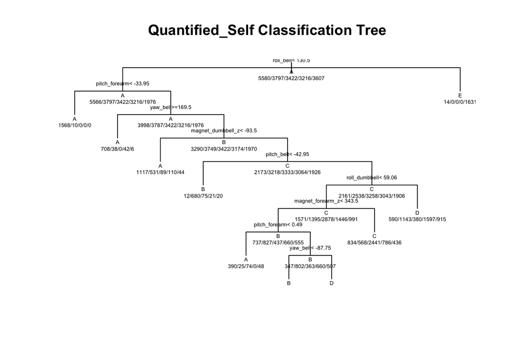

```r
plot(modF$finalModel, uniform=TRUE, main="Quantified_Self Classification Tree")
text(modF$finalModel, use.n=TRUE, all=TRUE, cex=.45)
```

We can now make use of the testing database, we prune it so that we can take the same covariates as we did for our training model and predict the values for the testing observations:

```r
testing <- read.csv("testing.csv",sep = ",", header=TRUE)
nv2 <- vector()
for(i in 1:dim(testing)[2]-1)
{
  if(class(testing[,i])=="numeric")
  {
    nv2 <- c(nv2,i)
  }
}
testing2 <- testing[,c(nv,dim(testing)[2])]
testing2[is.na(testing2)] <- 0.0
```

As in the following lines:

```r
pred2 <- predict(modF,testing2)
pred2
```

```
##  [1] C C C C A D C D A A D C B A C D C D C B
## Levels: A B C D E
```

Since the dependent variable is discrete and categorical we can say that if we were to apply an RMSE measure on it we would get the number of errors in the prediction.